# 0506习题课

本次习题课示例讲解一些有关综合作业（大作业）的内容，为后续综合作业的开展做准备。 另外提示综合练习1、2。

## 综合作业中需要掌握的知识点

多查看课件“20250508 中文分词应用与第三方库简介”，里面写的非常全面。

### 如何下载第三方库

第三方库的生态是 Python 强大的原因。著名的关于C、Java和Python各需要多少行完成一个任务的论断其实并不是说明Python语法简单，其实是因为其他的开发者已经将我们所需要的代码写好并封装在一个库中，所以才能用几行代码非常高效地完成一项工作。

将一门编程语言想象成一部手机，那第三方库就是上面各种各样的 App 。

如何下载？

1. 打开“应用市场”： https://pypi.org
2. 搜索下载命令：一般类似于 pip install xxx. 要从1步中查询的就是这个应用的xxx名
3. 使用“应用下载器”： pip(Package Installer for Python)

[figure not shown]

现场演示 pip 常用命令行命令：

- pip install(-U)
- pip list
- pip uninstall
- pip search
- pip help

jupyter中将对应pip install命令之前加一个%，就可以下载了：

```python
%pip install jieba
%pip install wordcloud
```

```python
import jieba
print(jieba.__version__)
```

```
0.42.1
```

### 一个典型场景：分词（jieba和wordcloud）

中文分词是自然语言处理的基础任务，能够将连续的文本分割成一个个独立的词语；词云则可以将文本中出现频率较高的 “关键词” 予以视觉上的突出，形成关键词的渲染分布。掌握这些技能，对文本分析、信息提取等工作具有重要意义。

jieba是由北大中文系相关团队开发的一个中文分词库，是业界标准。

精确模式试图将句子最精确地切开，适合文本分析。示例代码如下：

```python
import jieba

text = "我来到北京清华大学"
seg_list = jieba.lcut(text)
print("精确模式: " + "/ ".join(seg_list))
```

```
Building prefix dict from the default dictionary ...
Dumping model to file cache /var/folders/4p/tftskhfj113d00gg4vdz_hf40000gn/T/jieba.cache
Loading model cost 0.247 seconds.
Prefix dict has been built successfully.
```

```
精确模式: 我/ 来到/ 北京/ 清华大学
```

全模式会把句子中所有的可以成词的词语都扫描出来，速度非常快，但不能解决歧义。示例代码：

```python
import jieba

text = "我来到北京清华大学"
seg_list = jieba.lcut(text, cut_all=True)
print("全模式: " + "/ ".join(seg_list))
```

```
全模式: 我/ 来到/ 北京/ 清华/ 清华大学/ 华大/ 大学
```

搜索引擎模式在精确模式的基础上，对长词再次切分，提高召回率，适合用于搜索引擎分词。示例代码：

```python
import jieba

text = "我来到北京清华大学"
seg_list = jieba.lcut_for_search(text)
print("搜索引擎模式: " + "/ ".join(seg_list))
```

```
搜索引擎模式: 我/ 来到/ 北京/ 清华/ 华大/ 大学/ 清华大学
```

词云的用法非常多样，课件上给出了mask、字体等操作。以下给出一个演示

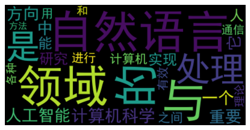

```python
import jieba
from wordcloud import WordCloud
import matplotlib.pyplot as plt

text = "自然语言处理是计算机科学领域与人工智能领域中的一个重要方向，它研究能实现人与计算机之间用自然语言进行有效通信的各种理论和方法"
seg_list = " ".join(jieba.lcut(text))
wordcloud = WordCloud(
            # 生成中文字的字体,必须要加,不然看不到中文
            # font_path="C:\Windows\Fonts\simhei.ttf"  # Windows端是这个
            font_path="~/Library/Fonts/SimHei.ttf"     # MacOS是这个地址
        ).generate(seg_list)

plt.imshow(wordcloud, interpolation='bilinear')
plt.axis("off")
plt.show()
```

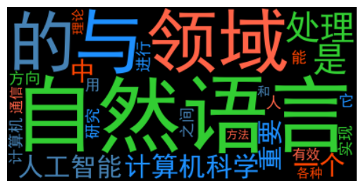

```python
import numpy as np
from wordcloud import WordCloud, ImageColorGenerator
import matplotlib.pyplot as plt

def color_func(word, font_size, position, orientation, random_state=None, **kwargs):
    color_list = ('#FF6347', '#4682B4', '#32CD32', '#FF4500', '#1E90FF')
    return np.random.choice(color_list)

text = "自然语言处理是计算机科学领域与人工智能领域中的一个重要方向，它研究能实现人与计算机之间用自然语言进行有效通信的各种理论和方法"
seg_list = " ".join(jieba.lcut(text))
wordcloud = WordCloud(
            # 生成中文字的字体,必须要加,不然看不到中文
            # font_path="C:\Windows\Fonts\simhei.ttf"  # Windows端是这个
            font_path="~/Library/Fonts/SimHei.ttf"     # MacOS是这个地址
            , color_func = color_func
        ).generate(seg_list)

plt.imshow(wordcloud, interpolation='bilinear')
plt.axis("off")
plt.show()
```

```python
%pip install imageio
%pip install pyav
```

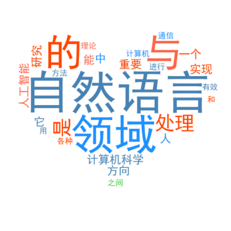

```python
import imageio
import numpy as np
from wordcloud import WordCloud
import matplotlib.pyplot as plt
mask_image = imageio.imread("word-cloud-mask.jpg")

def color_func(word, font_size, position, orientation, random_state=None, **kwargs):
    color_list = ('#FF6347', '#4682B4', '#32CD32', '#FF4500', '#1E90FF')
    return np.random.choice(color_list)

text = "自然语言处理是计算机科学领域与人工智能领域中的一个重要方向，它研究能实现人与计算机之间用自然语言进行有效通信的各种理论和方法"
seg_list = " ".join(jieba.lcut(text))
wordcloud = WordCloud(
            # 生成中文字的字体,必须要加,不然看不到中文
            # font_path="C:\Windows\Fonts\simhei.ttf"  # Windows端是这个
            font_path="~/Library/Fonts/SimHei.ttf"     # MacOS是这个地址
            , color_func = color_func, background_color = "white", mask=mask_image
        ).generate(seg_list)

plt.imshow(wordcloud, interpolation='bilinear')
plt.axis("off")
plt.show()
```

美化是无止境的，这里只给出一个功能性的示例，同学们可以在综合作业中自行探索。

## 综合作业

现场演示几个示例。

## 综合练习提示

### 1.1 爬楼梯

http://csc6.openjudge.cn/2025hw7/01/

#### 描述

楼梯有n(0< n <= 20)阶台阶，上楼时可以一步上1阶，也可以一步上2阶，编程计算共有多少种不同的爬楼梯的方法。

#### 输入

一行，即台阶数n。

#### 输出

一行，输出走法的数目。

#### 解法

我们可以从最后一步的情况来考虑。假设要爬到第 n 阶台阶，那么最后一步可能有两种情况：

- 最后一步是从第 n - 1 阶台阶走 1 步上来的。
- 最后一步是从第 n - 2 阶台阶走 2 步上来的。

所以，爬到第 n 阶台阶的方法数就等于爬到第 n - 1 阶台阶的方法数加上爬到第 n - 2 阶台阶的方法数。

用数学公式表示就是： $$f(n) = f(n - 1) + f(n - 2)$$ 其中 f(n) 表示爬到第 n 阶台阶的方法数。

同时，我们需要确定递归的边界条件：

- 当 n = 1 时，只有一种走法，就是一步走 1 阶台阶，即 f(1) = 1。
- 当 n = 2 时，有两种走法：一步走 2 阶台阶或者分两步，每次走 1 阶台阶，即 f(2) = 2。

```python
def f(n):
    # 边界条件: 当 n 为 1 或 2 时，直接返回对应的走法数目。
    if n == 1:
        return 1
    if n == 2:
        return 2
    # 否则递归调用
    return f(n - 1) + f(n - 2)

# 读取输入
n = int(input())
# 计算并输出结果
print(f(n))
```

```
89
```

如果使用动态规划，我们可以用一个数组来保存每一个台阶的走法数目，然后根据递推公式 f(n) = f(n - 1) + f(n - 2) 依次计算出每个台阶的走法数目。

```python
def climb_stairs_dp(n):
    if n == 1:
        return 1
    if n == 2:
        return 2
    # 创建一个数组来保存每一个台阶的走法数目
    dp = [0] * (n + 1)
    dp[1] = 1
    dp[2] = 2
    # 从第 3 阶台阶开始依次计算每一个台阶的走法数目
    for i in range(3, n + 1):
        dp[i] = dp[i - 1] + dp[i - 2]
    return dp[n]

# 读取输入
n = int(input())
# 计算并输出结果
print(climb_stairs_dp(n))
```

```
89
```

### 1.2 公约数和公倍数（递归）

http://csc6.openjudge.cn/2025hw7/02/

#### 描述

求给定两个数的最大公约数和最小公倍数。

本题要求编写函数，使用递归的方法来实现。

#### 输入

共n+1行；第一行为正整数n； 下面紧跟n行，每行包括两个正整数，用空格隔开。

#### 输出

共输出n行； 每行输出最大公约数和最小公倍数，中间用一个空格隔开。

辗转相除法就很适合使用递归，因为它描述的方法就是前一次和后一次的关系。

假定b较小，是a的因数，能整除时就是最大公因数了。数学证明可以不用深究，本课程中简单记忆即可（和求素数一样是比较基本的模板）。

```python
def gcd(a, b):
    if b == 0:
        return a
    return gcd(b, a % b)

def lcm(a, b):
    return a * b // gcd(a, b)

n = int(input())
for _ in range(n):
    num1, num2 = map(int, input().split())
    print(gcd(num1, num2), lcm(num1, num2))
```

### 1.3 塔形列表

http://csc6.openjudge.cn/2025hw7/03/

#### 描述

接收一个正整数t作为参数，输出t行，每行1个列表，每个列表两端的数字对应着该列表所在的行号，内部每个位置上的数字都是其上方列表中相邻两个数字的和。

#### 输入

一个正整数t，表示列表的个数

#### 输出

t个顺序创建的相互关系满足题目要求的列表

#### 解法

假设输入 t = 4，我们来看看输出情况：

- 第 1 行：列表只有一个元素，就是行号 1，即 [1]。
- 第 2 行：列表两端是行号 2，由于上一行只有一个元素，所以中间没有 “上方列表相邻两个数字求和” 的操作，即 [2, 2]。
- 第 3 行：列表两端是行号 3，中间数字是上一行相邻数字之和（这里上一行是 [2, 2]，2 + 2 = 4），即 [3, 4, 3]。
- 第 4 行：列表两端是行号 4，中间数字是上一行相邻数字之和（上一行 [3, 4, 3]，3 + 4 = 7，4 + 3 = 7），即 [4, 7, 7, 4]。

初始化：当 t 为 1 时，直接返回 [1]；当 t 为 2 时，先有 [1]，再有 [2, 2]。 迭代生成后续列表：从第 3 行开始，对于每一行，先将行号作为列表的首尾元素，然后根据上一行列表相邻元素求和填充中间部分。

```python
'''
[1]
[2, 2]     <- last_list
[3, 4, 3]  <- cur_list
[4, 7, 7, 4]

[1]
[2, 2]
[3, 3, 3]
[4, 4, 4, 4]
'''
n = int(input())
if n == 1:
    print([1])
else:
    last_list = [1]  # last_list保存上一行的
    print([1])
    for i in range(2, n+1):
        cur_list = [i] * i  # 当前行的
        for j in range(1, i-1):  # 跳过当前行的头尾（注意看示例，因为最后会多出来一个）
            cur_list[j] = last_list[j-1] + last_list[j]
        last_list = cur_list
        print(cur_list)
```

### 1.4 运动记录

http://csc6.openjudge.cn/2025hw7/04/

#### 描述

多名同学一次或多次进入操场锻炼，假设操场有多个门，

进场一定刷卡，出场一定刷卡，进出可能不是同一个门。

因某种原因多个门的数据已融合在一起，数据未必按时间先后顺序排列。

编写程序计算出当日每位同学锻炼总时长，以秒为单位。

#### 输入

输入姓名和时间，直到输入QUIT结束。

姓名和时间之间以英文逗号分隔。

姓名之间可能有空格，但不会有逗号。

时间仅都为当日时间，只有小时分钟秒形如09:23:47，24小时制，用英文冒号间隔。

#### 输出

以锻炼时长为序，按降序输出，如锻炼时长相同，则按姓名降序。

输出包括姓名和时长，以英文逗号间隔，时长以秒为单位。

#### 解法

因为合并之后不是严格时间顺序的记录，所以需要存储数据：使用字典来存储每位同学的刷卡记录，键为同学的姓名，值为一个列表，列表中存储每次刷卡的时间。

为了方便计算时间差和排序，将时间字符串转换为秒数。

计算时长使用统计题目模板：遍历每位同学的刷卡记录，按照刷卡顺序计算每次进出操场的时间差，并累加到总时长中。

```
words = []
count_dict = {}

# 输入

# 遍历
for word in words:
    # 方法2（推荐）：用get()方法设置默认值
    count_dict[word] = count_dict.get(word, 0) + 1

# 输出
for k, v in count_dict.items():
    print(k, v)
```

```python
enter_time = {}
time_count = {}

def time_seconds(time1):
    h1, m1, s1 = map(int, time1.split(":"))
    return s1 + m1 * 60 + h1 * 3600

while True:
    line = input()
    if line == "QUIT":
        break
    name, time = line.split(',')
    enter_time[name] = enter_time.get(name, []) + [time_seconds(time)]

for k, v in enter_time.items():
    l = sorted(v)
    for i in range(0, len(l), 2):
        time_count[k] = time_count.get(k, 0) + l[i+1] - l[i]

for k, v in sorted(time_count.items(), key=lambda x: -x[1]):
    print(f"{k},{v}")
```

### 2.2 病毒传播

http://csc6.openjudge.cn/homework8/2/

#### 描述

有一条河流，在河流的一端存在若干个村子，其中某些村子在第一天已经存在了某种具备传染性的病毒，该村子标记为“*”；而没有存在病毒的村子则被标记为“#”。

在第二天的开始，存在病毒的村子会向相邻的两个村子传播病毒；

但是第二天刚被传播病毒的村子不会向相邻的村子传播病毒，如

第一天状态为“*##”，第二天状态则为“**#”。

#### 输入

一行，为一个字符串，只有两种字符，为"*""#",分别表示存在病毒的村子和不存在病毒的村子。

#### 输出

一个数字，即第二天时未存在病毒的村子数。

#### 解法

这个题目容易理解，但很多出错的原因在于没有考虑边界问题。

```python
village_status = input()
status_list = list(village_status)
length = len(status_list)

for i in range(length):
    if village_status[i] == '*':
        # 向左传播
        if i > 0:
            status_list[i - 1] = '*'
        # 向右传播
        if i < length - 1:
            status_list[i + 1] = '*'

virus_count = status_list.count('#')
print(virus_count)
```